# Rapport Final : Développement et Validation d’un Modèle de Régression

Mohamed

2026-04-29

## Introduction

Ce rapport analyse les **dépenses totales des clients** d’une entreprise de vente au détail numérique. L’objectif est de construire et valider un modèle prédictif pour expliquer ce qui motive les dépenses et générer des prédictions pour les futures campagnes marketing.

## Challenge 1 : Préparation et Exploration des Données

### Chargement des packages et du dataset

```r
library(tidyverse)
library(broom)
library(car)
library(ggplot2)
library(tibble)
library(dplyr)
library(knitr)

# Chargement du dataset
analysis_df <- read_csv("regression_model_final.csv")
head(analysis_df)
```

```
## # A tibble: 6 × 10
##   CustomerID SignupDate   Age Income WebVisits NewsletterSubscriber DeviceUsed
##        <dbl> <date>     <dbl>  <dbl>     <dbl> <chr>                <chr>
## 1       1521 2022-01-01    61 51957.         4 No                   Mobile
## 2       1737 2022-01-08    19 55704.         5 Yes                  Mobile
## 3       1740 2022-01-15    30 81732.         8 No                   Desktop
## 4       1660 2022-01-22    57 63854.         5 Yes                  Desktop
## 5       1411 2022-01-29    19 58253.         4 No                   Mobile
## 6       1678 2022-02-05    37 61632.         8 Yes                  Desktop
## # ℹ 3 more variables: PurchaseHistoryScore <dbl>, DaysSinceLastPurchase <dbl>,
## #   TotalSpend <dbl>
```

### Nettoyage des données

```r
# Conversion en numérique et suppression des valeurs manquantes
analysis_df <- analysis_df %>%
  mutate(
    Income     = as.numeric(Income),
    Age        = as.numeric(Age),
    TotalSpend = as.numeric(TotalSpend)
  ) %>%
  drop_na()

cat("Nombre de lignes après nettoyage :", nrow(analysis_df), "\n")
```

```
## Nombre de lignes après nettoyage : 150
```

### Statistiques descriptives

```r
mean_income     <- mean(analysis_df$Income,     na.rm = TRUE)
mean_age        <- mean(analysis_df$Age,         na.rm = TRUE)
mean_totalspend <- mean(analysis_df$TotalSpend,  na.rm = TRUE)

sd_income     <- sd(analysis_df$Income,     na.rm = TRUE)
sd_age        <- sd(analysis_df$Age,         na.rm = TRUE)
sd_totalspend <- sd(analysis_df$TotalSpend,  na.rm = TRUE)

# Tableau résumé
stats_table <- data.frame(
  Variable  = c("Income", "Age", "TotalSpend"),
  Moyenne   = round(c(mean_income, mean_age, mean_totalspend), 2),
  Ecart_type = round(c(sd_income, sd_age, sd_totalspend), 2)
)

kable(stats_table, caption = "Statistiques descriptives des variables clés")
```

Statistiques descriptives des variables clés

| Variable | Moyenne | Ecart_type |
| --- | --- | --- |
| Income | 53698.12 | 15799.64 |
| Age | 43.39 | 15.10 |
| TotalSpend | 1202.26 | 328.35 |

## Challenge 2 : Visualisation des Données

### Distribution des dépenses totales

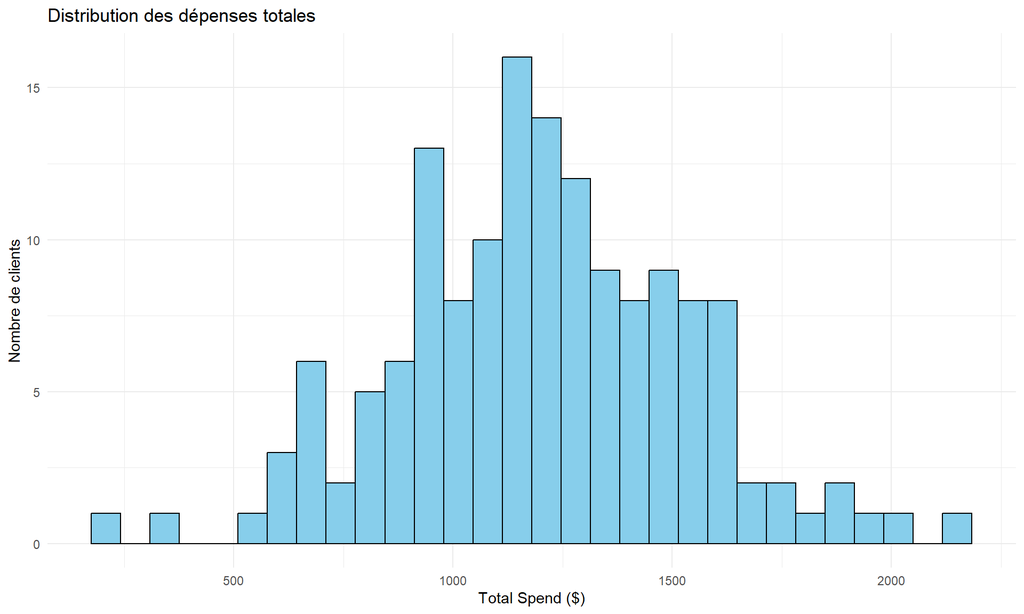

```r
plot_1 <- ggplot(analysis_df, aes(x = TotalSpend)) +
  geom_histogram(fill = "skyblue", color = "black", bins = 30) +
  labs(
    title = "Distribution des dépenses totales",
    x     = "Total Spend ($)",
    y     = "Nombre de clients"
  ) +
  theme_minimal()

print(plot_1)
```

### Revenu vs Dépenses totales par appareil

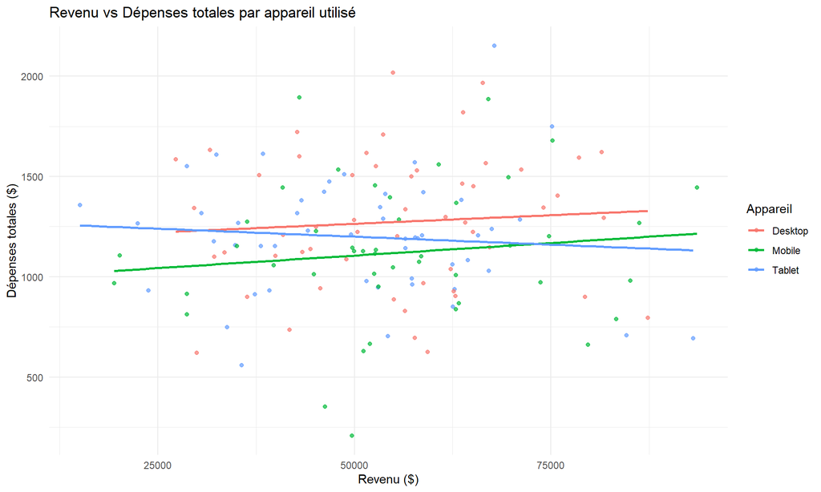

```r
plot_2 <- ggplot(analysis_df, aes(x = Income, y = TotalSpend, color = DeviceUsed)) +
  geom_point(alpha = 0.7) +
  geom_smooth(method = "lm", se = FALSE) +
  labs(
    title = "Revenu vs Dépenses totales par appareil utilisé",
    x     = "Revenu ($)",
    y     = "Dépenses totales ($)",
    color = "Appareil"
  ) +
  theme_minimal()

print(plot_2)
```

> **Interprétation :** - Les utilisateurs **Desktop** montrent une tendance positive légère - Les utilisateurs **Mobile** montrent une tendance positive plus marquée - La corrélation globale entre revenu et dépenses est **très faible**

> **Recommandations :** - 🎯 Cibler les campagnes sur les utilisateurs mobiles à haut revenu - 💡 Développer des offres personnalisées selon l’historique d’achat

## Challenge 3 : Développement du Modèle

### Modèle de régression simple

```r
model_simple <- lm(TotalSpend ~ Income, data = analysis_df)

r_squared_simple <- summary(model_simple)$r.squared
slope_simple     <- coef(model_simple)["Income"]

cat("R-squared :", round(r_squared_simple, 4), "\n")
```

```
## R-squared : 0.0015
```

```r
cat("Pente     :", round(slope_simple, 6),     "\n")
```

```
## Pente     : 0.000804
```

> **Interprétation :** R² = **0.0015** → Income n’explique que **0.15%** de la variance de TotalSpend. Le revenu seul est un **très mauvais prédicteur** des dépenses.

### Modèle de régression multiple

```r
model_multi <- lm(TotalSpend ~ Income + Age + PurchaseHistoryScore, data = analysis_df)

model_summary    <- summary(model_multi)
broom_evaluation <- broom::glance(model_multi)

print(model_summary)
```

```
##
## Call:
## lm(formula = TotalSpend ~ Income + Age + PurchaseHistoryScore,
##     data = analysis_df)
##
## Residuals:
##     Min      1Q  Median      3Q     Max
## -944.79 -211.07   -2.13  203.32  915.89
##
## Coefficients:
##                        Estimate Std. Error t value Pr(>|t|)
## (Intercept)           1.300e+03  2.288e+02   5.684 6.91e-08 ***
## Income                9.285e-04  1.708e-03   0.543    0.588
## Age                   2.358e+00  1.783e+00   1.322    0.188
## PurchaseHistoryScore -3.331e+00  2.745e+00  -1.214    0.227
## ---
## Signif. codes:  0 '***' 0.001 '**' 0.01 '*' 0.05 '.' 0.1 ' ' 1
##
## Residual standard error: 328 on 146 degrees of freedom
## Multiple R-squared:  0.02204,    Adjusted R-squared:  0.001947
## F-statistic: 1.097 on 3 and 146 DF,  p-value: 0.3525
```

```r
kable(broom_evaluation, caption = "Évaluation du modèle multiple avec broom::glance()")
```

Évaluation du modèle multiple avec broom::glance()

| r.squared | adj.r.squared | sigma | statistic | p.value | df | logLik | AIC | BIC | deviance | df.residual | nobs |
| --- | --- | --- | --- | --- | --- | --- | --- | --- | --- | --- | --- |
| 0.0220421 | 0.001947 | 328.0334 | 1.096892 | 0.3525112 | 3 | -1079.781 | 2169.562 | 2184.615 | 15710459 | 146 | 150 |

> **Interprétation :** R² = **0.022** → Le modèle multiple explique seulement **2.2%** de la variance. La p-value de **0.3525** indique que le modèle **n’est pas significatif**. D’autres variables non incluses expliquent mieux TotalSpend.

## Challenge 4 : Validation et Prédiction

### Graphiques de diagnostic

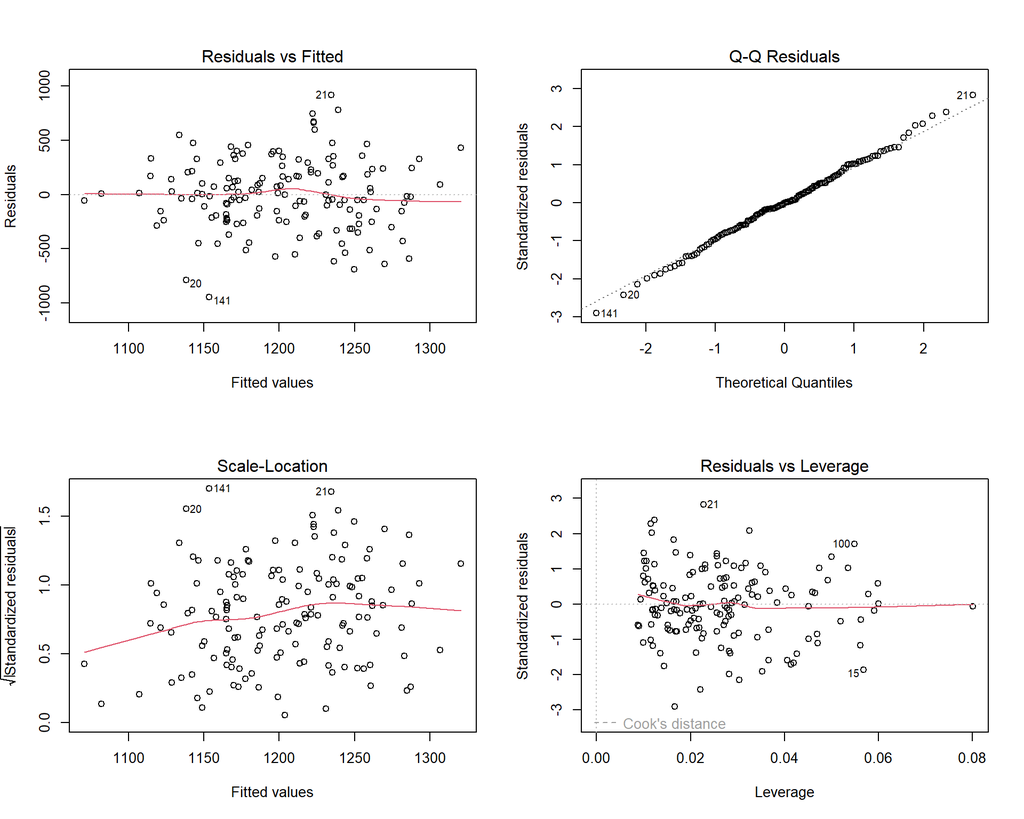

```r
par(mfrow = c(2, 2))
plot(model_multi)
```

> **Interprétation :** - **Residuals vs Fitted** : résidus aléatoires, pas de non-linéarité évidente ✅ - **Q-Q Plot** : points alignés sur la diagonale, normalité confirmée ✅ - **Scale-Location** : variance relativement constante ✅ - **Residuals vs Leverage** : pas de points très influents ✅

### Vérification de la multicolinéarité (VIF)

```r
vif_results <- vif(model_multi)
kable(as.data.frame(vif_results), caption = "Facteurs d'Inflation de la Variance (VIF)")
```

Facteurs d’Inflation de la Variance (VIF)

|  | vif_results |
| --- | --- |
| Income | 1.008815 |
| Age | 1.003341 |
| PurchaseHistoryScore | 1.010827 |

> **Interprétation :** Toutes les valeurs VIF sont proches de **1**, bien inférieures au seuil de 5. **Pas de multicolinéarité** entre les prédicteurs ✅

### Test de normalité des résidus

```r
shapiro_result <- shapiro.test(residuals(model_multi))
print(shapiro_result)
```

```
##
##  Shapiro-Wilk normality test
##
## data:  residuals(model_multi)
## W = 0.99714, p-value = 0.9936
```

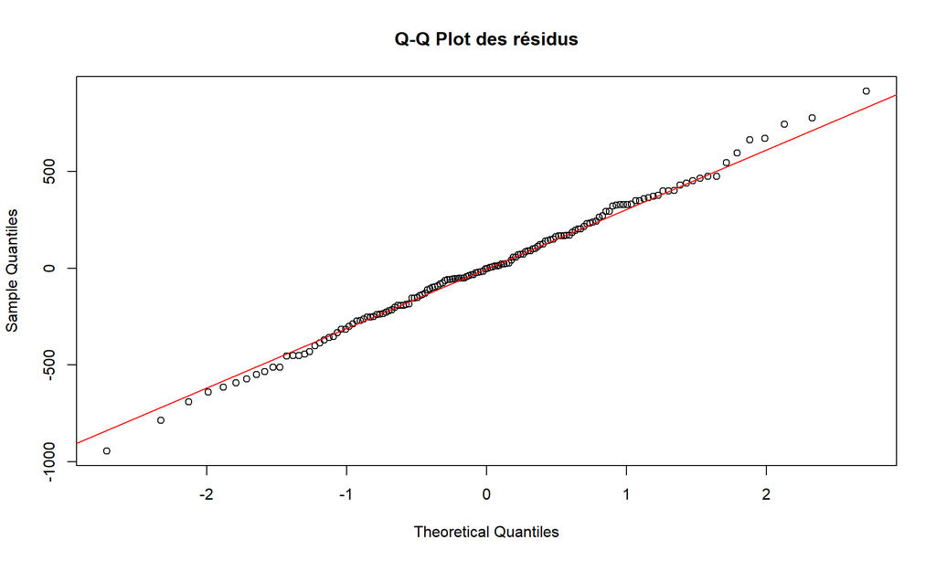

```r
qqnorm(residuals(model_multi), main = "Q-Q Plot des résidus")
qqline(residuals(model_multi), col = "red")
```

> **Interprétation :** p-value = **0.9936** >> 0.05 → Les résidus suivent une **distribution normale** ✅

### Prédictions pour nouveaux clients

```r
new_profiles <- tibble(
  Income               = c(45000, 65000, 80000),
  Age                  = c(25, 35, 40),
  PurchaseHistoryScore = c(3, 7, 8)
)

prediction_intervals <- predict(model_multi,
                                newdata  = new_profiles,
                                interval = "prediction")

results <- cbind(new_profiles, round(as.data.frame(prediction_intervals), 2))
kable(results, caption = "Prédictions avec intervalles de confiance")
```

| Income | Age | PurchaseHistoryScore | fit | lwr | upr |
| --- | --- | --- | --- | --- | --- |
| 45000 | 25 | 3 | 1391.15 | 631.80 | 2150.50 |
| 65000 | 35 | 7 | 1419.97 | 669.28 | 2170.66 |
| 80000 | 40 | 8 | 1442.36 | 687.93 | 2196.78 |

> **Interprétation :** - Client 1 (45k$, 25 ans) → **1391$** [632$ - 2150$] - Client 2 (65k$, 35 ans) → **1420$** [669$ - 2171$] - Client 3 (80k$, 40 ans) →** 1442$** [688$ - 2197$]

> Les intervalles larges reflètent la **faible précision** du modèle.

### Régression logistique — Probabilité d’être HighSpender

```r
analysis_df_final <- analysis_df %>%
  mutate(HighSpender = ifelse(TotalSpend > 500, TRUE, FALSE))

logistic_model <- glm(
  HighSpender ~ Income + Age + PurchaseHistoryScore,
  data   = analysis_df_final,
  family = "binomial"
)

test_customer <- tibble(
  Income               = 50000,
  Age                  = 40,
  PurchaseHistoryScore = 70
)

predicted_probability <- predict(
  logistic_model,
  newdata = test_customer,
  type    = "response"
)

cat("Probabilité HighSpender :", round(predicted_probability * 100, 2), "%\n")
```

```
## Probabilité HighSpender : 99.44 %
```

## Conclusion

| Élément | Résultat |
| --- | --- |
| **R² modèle simple** | 0.0015 → Income seul insuffisant |
| **R² modèle multiple** | 0.022 → modèle non significatif |
| **VIF** | < 2 → Pas de multicolinéarité ✅ |
| **Shapiro-Wilk** | p = 0.9936 → Résidus normaux ✅ |
| **Probabilité HighSpender** | 99.44% → Client à fort potentiel |

> **Recommandation finale :** Collecter des variables supplémentaires *(fidélité, fréquence d’achat)* pour améliorer la puissance prédictive du modèle.